# SA24204134_HW

SA24204134

# HW_0

## Demostration 1

In this example, we perform a two-sample t-test to compare the means of two groups. The null hypothesis is that there is no significant difference between the groups:

$$H_0: \mu_1 = \mu_2$$

where $\mu_1$ and $\mu_2$ are the means of Group 1 and Group 2, respectively.

```r
library(knitr)
set.seed(123)
group1 <- rnorm(50, mean = 5, sd = 1)
group2 <- rnorm(50, mean = 6, sd = 1)

t_test_result <- t.test(group1, group2)
kable(t_test_result$statistic, caption = "t-Test Results")
```

t-Test Results

|  | x |
| --- | --- |
| t | -6.07178 |

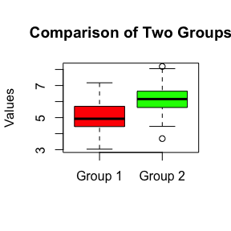

```r
boxplot(group1, group2, names = c("Group 1", "Group 2"),
      main = "Comparison of Two Groups", ylab = "Values", col = c("red", "green"))
```

These examples demonstrate how to use `knitr` to create dynamic reports that mix text, code, tables, figures, and mathematical formulas in a single document.

## Demostration 2

In this example, we analyze a simple linear regression model to understand the relationship between two variables: `x` and `y`. The model is defined as:

$$y = \beta_0 + \beta_1 x + \epsilon$$

where: - $y$ is the dependent variable. - $x$ is the independent variable. - $\beta_0$ is the intercept. - $\beta_1$ is the slope. - $\epsilon$ is the error term.

```r
# Load necessary libraries
library(ggplot2)
library(knitr)

set.seed(123)
x <- rnorm(100, mean = 5, sd = 2)
y <- 3 + 1.5 * x + rnorm(100)
data <- data.frame(x, y)

model <- lm(y ~ x, data = data)
kable(summary(model)$coefficients, caption = "Regression Coefficients")
```

Regression Coefficients

|  | Estimate | Std. Error | t value | Pr(>\|t\|) |
| --- | --- | --- | --- | --- |
| (Intercept) | 3.028376 | 0.2933833 | 10.32225 | 0 |
| x | 1.473764 | 0.0534393 | 27.57828 | 0 |

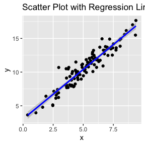

```r
ggplot(data, aes(x = x, y = y)) +
  geom_point() +
  geom_smooth(method = "lm", col = "blue") +
  labs(title = "Scatter Plot with Regression Line", x = "x", y = "y")
```

## Demostration 3

The table below shows the descriptive statistics for the variables Sepal.Length, Sepal.Width, Petal.Length, and Petal.Width from the iris dataset.

Descriptive Statistics of the Iris Dataset

|  | Sepal.Length | Sepal.Width | Petal.Length | Petal.Width | Species |
| --- | --- | --- | --- | --- | --- |
|  | Min. :4.300 | Min. :2.000 | Min. :1.000 | Min. :0.100 | setosa :50 |
|  | 1st Qu.:5.100 | 1st Qu.:2.800 | 1st Qu.:1.600 | 1st Qu.:0.300 | versicolor:50 |
|  | Median :5.800 | Median :3.000 | Median :4.350 | Median :1.300 | virginica :50 |
|  | Mean :5.843 | Mean :3.057 | Mean :3.758 | Mean :1.199 | NA |
|  | 3rd Qu.:6.400 | 3rd Qu.:3.300 | 3rd Qu.:5.100 | 3rd Qu.:1.800 | NA |
|  | Max. :7.900 | Max. :4.400 | Max. :6.900 | Max. :2.500 | NA |

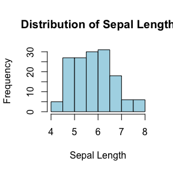

# Hw_1

## Question 3.4

- 本题采用逆变换法构造Rayleigh分布随机数，一共10000个。
- 从生成的随机数频率直方图和Rayleigh分布密度函数图象对比可以看出高度吻合。

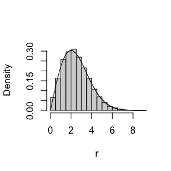

```r
# 设置随机种子。
set.seed(123)

# 生成10000个U(0, 1)随机数。
n <- 1e4
u <- runif(n)

# 设置参数sigma的取值。
sigma <- 2

# 基于逆变换法构造Rayleigh分布随机数。
r <- sqrt(-2*sigma^2*log(1-u))

# 绘制r随机数频率直方图。
hist(r, probability=TRUE, main=expression())

y <- seq(0, 10, .01)
lines(y, y/sigma^2*exp(-y^2/(2*sigma^2)))
```

## Question 3.11

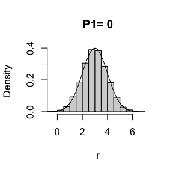

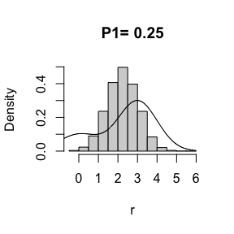

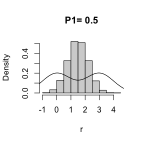

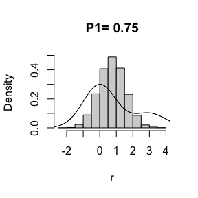

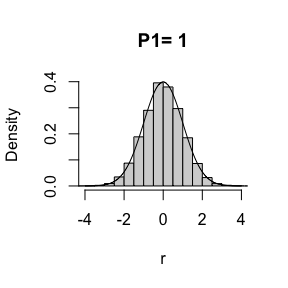

```r
set.seed(123)
n <- 1e4
u1 <- rnorm(n)
u2 <- rnorm(n, 3, 1)

p1 <- c(0, .25, .50, .75, 1)

i <- 1

while(i < 6){
  r <- p1[i]*u1 + (1-p1[i])*u2
  hist(r, probability = TRUE, main=paste("P1=", p1[i]))
  y <- seq(-6, 6, .01)
  lines(y, p1[i]*(1/sqrt(2*pi)*exp(-y^2/2))+(1-p1[i])*(1/sqrt(2*pi)*exp(-(y-3)^2/2)))

  i <- i+1
}
```

## Question 3.20

- 定义生成随机数的函数。个数n=10000，时刻t=10。
- 采用均值、方差理论值和估计值的比值来评估生成效果，越接近于1效果越好。

```r
set.seed(123)
# 定义生成随机数函数。
rand_func <-function(lambda, alpha, beta){
  # lambda为pisson分布参数，alpha为伽马分布尺度参数，beta为伽马分布形状参数。
  n <- 10000 # 定义生成的随机数个数。
  X <- numeric(length= n) # 定义随机数数组。
  t <- 10 # 定义时刻。

  i <- 0 # 初始化。
  while(i < n){
    i <- i + 1
    N_t = rpois(1, lambda*t)
    y <- rgamma(N_t, shape= alpha, rate= 1/beta)
    X[i] <- sum(y)
  }

  # X_t的理论均值和方差。
  E_X_t <- lambda*t*alpha*beta
  Var_X_t <- lambda*t*(alpha*(1+alpha)*beta^2)

  # 比较X_t均值，方差的估计值和理论值的差异。
  result <- c(mean(X)/E_X_t, var(X)/Var_X_t)

  return(result)
}
```

- 检验效果，设定不同参数，比较X_t均值，方差的估计值和理论值的比值。
- 从得到的结果来看，效果良好。
- lambda=1, alpha=2, beta=3:

```r
# lambda=1, alpha=2, beta=3
rand_func(1, 2, 3)
```

```
## [1] 0.9999424 1.0034711
```

```r
# lambda=3, alpha=1, beta=2
rand_func(3, 1, 2)
```

```
## [1] 1.0039022 0.9888777
```

```r
# lambda=2, alpha=3, beta=1
rand_func(2, 3, 1)
```

```
## [1] 1.0020869 0.9895752
```

# Hw_2

## Question 5.4

```r
# 定义估计函数。
est_beta <- function(x){
  n <- 1e4
  r <- runif(n, 0, x)
  s <- 30*(r^2)*((1-r)^2)*x
  est <- round(mean(s), 5)
  return(est)
}

# 调用函数，生成不同x取值下的cdf估计值。
set.seed(42)
x <- seq(0.1, 0.9, 0.1)
i <- 0
est_cdf <- c()
real_cdf <- c()

while(i < 9){
  i <- i + 1
  est_cdf[i] <- est_beta(x[i])
  real_cdf[i] <- pbeta(x[i], 3, 3)
}

# 输出估计值和实际值。
print("beta(3,3)累积分布函数值估计值：")
```

```
## [1] "beta(3,3)累积分布函数值估计值："
```

```r
est_cdf
```

```
## [1] 0.00856 0.05751 0.16266 0.32012 0.50436 0.68506 0.84083 0.94083 0.99134
```

```r
print("beta(3,3)累积分布函数值实际值：")
```

```
## [1] "beta(3,3)累积分布函数值实际值："
```

```r
real_cdf
```

```
## [1] 0.00856 0.05792 0.16308 0.31744 0.50000 0.68256 0.83692 0.94208 0.99144
```

```r
# 比较估计值和实际值。
print("beta(3,3)累积分布函数值估计值与实际值的比值：")
```

```
## [1] "beta(3,3)累积分布函数值估计值与实际值的比值："
```

```r
round(est_cdf / real_cdf, 5)
```

```
## [1] 1.00000 0.99292 0.99742 1.00844 1.00872 1.00366 1.00467 0.99867 0.99990
```

## Question 5.9

```r
set.seed(42)
sample_rayleigh <- function(n, sigma){ # 生成n个参数为sigma的Rayleigh分布随机数。
  # 生成两个独立的Rayleigh分布的随机样本，并取平均值。
  r1 <- (sigma * sqrt(-2 * log(runif(n)))+sigma * sqrt(-2 * log(runif(n))))/2
  # 生成一个均匀分布样本，并用antithetic方法生成一个Rayleigh分布的随机样本。
  ru <- runif(n)
  r2 <- (sigma * sqrt(-2 * log(ru))+sigma * sqrt(-2 * log(1-ru)))/2

  # 计算方差和百分比。
  var_1 <- var(r1)
  var_2 <- var(r2)
  percent_reduction <- abs((var(r2)-var(r1))/var(r1))

  result <- round(c(var_1, var_2, percent_reduction), 5)
  # 返回值。
  return(result)

}


# 调用函数。
result <- sample_rayleigh(1e4, 1) # 生成10000个参数为1的Rayleigh分布随机数。
cat("生成两个独立的Rayleigh分布的随机样本方差为：", result[1], end="\n")
```

```
## 生成两个独立的Rayleigh分布的随机样本方差为： 0.21805
```

```r
cat("对偶方法生成一个Rayleigh分布的随机样本方差为：", result[2], end="\n")
```

```
## 对偶方法生成一个Rayleigh分布的随机样本方差为： 0.01183
```

```r
cat("方差减少的百分比为：", result[3], end="\n")
```

```
## 方差减少的百分比为： 0.94575
```

## Question 5.13

$g(x)=\frac{x^2}{\sqrt{2 \pi}} e^{-x^2 / 2}, \quad x>1$

我们可以找到两个important function：
$$f_1=\frac{1}{\sqrt{2 \pi}*p_1} e^{-x^2 / 2},
\quad x>1$$
其中$p_1$是标准正态分布随机变量大于1的概率。

$$f_2=\frac{x^2}{2*p_2} e^{-x^2 / 2},
\quad x>1$$
其中$p_2$是参数为1的瑞利分布随机变量大于1的概率。

接下来进行试验验证。

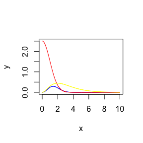

```r
# 设置随机数种子。
set.seed(42)
# 生成随机数个数。
n <- 1e6

# 生成服从标准正态分布和参数为1的瑞利分布的随机数。
r_norm <- rnorm(n)
r_rayleigh <- sqrt(-2 * log(runif(n)))

# 筛选出大于1的随机数，并计算其频率，用来估计对应概率。
r1 <- r_norm[r_norm>1]
r2 <- r_rayleigh[r_rayleigh>1]

p1 <- length(r1)/n
p2 <- length(r2)/n

# 画出g(x), f_1(x), f_2(x)的函数图象，进行比较，其中概率用频率估计。
x <- seq(0, 10, 0.01)
g <- x^2/(sqrt(2*pi))*exp(-x^2/2)
f_1 <- 1/(sqrt(2*pi))*exp(-x^2/2)/p1
f_2 <- x^2/2*exp(-x)/p2

plot(x, g, type = 'l', col='blue',ylim = c(0, 2.5), ylab = "y")
lines(x, f_1, type = 'l', col="red")
lines(x, f_2, type = 'l', col="yellow")
```

```r
# 估计量相关函数表达式。
g <- 1/sqrt(2*pi)*r1^2*exp(-x^2/2)
f1 <- 1/sqrt(2*pi)*exp(-x^2/2)/p1
f2 <- r2^2/2*exp(-r2^2/2)/p2

# 计算估计值及估计值的方差。
est1 <- mean(g/f1)
var1 <- var(g/f1)
est2 <- mean(g/f2)
var2 <- var(g/f2)
# 输出结果。
cat("由重要性函数f_1得到的积分估计值：",est1, end="\n")
```

```
## 由重要性函数f_1得到的积分估计值： 0.4013999
```

```r
cat("由重要性函数f_1得到的积分估计值的方差：",var1, end="\n")
```

```
## 由重要性函数f_1得到的积分估计值的方差： 0.06861075
```

```r
cat("由重要性函数f_2得到的积分估计值：",est2, end="\n")
```

```
## 由重要性函数f_2得到的积分估计值： 0.3908936
```

```r
cat("由重要性函数f_2得到的积分估计值的方差：",var2, end="\n")
```

```
## 由重要性函数f_2得到的积分估计值的方差： 36.33402
```

从图象可以看出，用标准正态分布函数来作为重要性函数，其方差减小效果比瑞利分布要好。

从实际随机数试验结果来看，标准正态分布作为重要性函数，估计方差为0.06861， 远小于瑞利分布函数作为重要性函数，得到的估计两方差36.33402。

但是两种重要性函数得到的估计值都是无偏的，与积分真实值0.40062相差不大。

## Question Monte Calro Experient

For $n=10^4, 2 \times 10^4, 4 \times 10^4, 6 \times 10^4, 8 \times 10^4$, apply the fast sorting algorithm to randomly permuted numbers of $1, \ldots, n$. Calculate computation time averaged over 100 simulations, denoted by $a_n$. Regress $a_n$ on $t_n:=n \log (n)$, and graphically show the results (scatter plot and regression line).

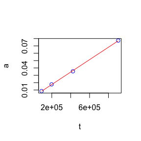

```r
# 定义快速排序法函数。
quick_sort<-function(x){
  num<-length(x)
  if(num==0||num==1){return(x)
  }else{
    a<-x[1]
    y<-x[-1]
    lower<-y[y<a]
    upper<-y[y>=a]
    return(c(quick_sort(lower),a,quick_sort(upper)))}#??????
}


# 定义生成的随机数个数并初始化。
n <-c(1, 2, 4, 8)*1e4
i <- 0
n_len <- length(n)
a <-c()

# 采用循环处理不同随机数个数的情况。
while(i<n_len){
  i <- i+1
  time_i <-c()
  j <- 0
  while(j<100){ # 对每个n，进行100次排序，计算平均时间。
    j <- j+1
    test<-sample(1:n[i])
    time_i[j] <- system.time(quick_sort(test))[1]
  }
  a[i] <- mean(time_i)
}

# 定义时间复杂度。
t <- n*log(n)

model <- lm(a~t)

a_predict <- predict(model)

plot(t, a, col="blue")
lines(t, a_predict, col="red")
```

```r
# 其统计结果输出。
summary(model)
```

```
##
## Call:
## lm(formula = a ~ t)
##
## Residuals:
##          1          2          3          4
##  0.0002503  0.0003488 -0.0009367  0.0003376
##
## Coefficients:
##              Estimate Std. Error t value Pr(>|t|)
## (Intercept) 5.605e-04  6.275e-04   0.893 0.466011
## t           8.457e-08  1.229e-09  68.819 0.000211 ***
## ---
## Signif. codes:  0 '***' 0.001 '**' 0.01 '*' 0.05 '.' 0.1 ' ' 1
##
## Residual standard error: 0.0007667 on 2 degrees of freedom
## Multiple R-squared:  0.9996, Adjusted R-squared:  0.9994
## F-statistic:  4736 on 1 and 2 DF,  p-value: 0.0002111
```

# Hw_3

## Question 5.4

```r
# 定义估计函数。
est_beta <- function(x){
  n <- 1e4
  r <- runif(n, 0, x)
  s <- 30*(r^2)*((1-r)^2)*x
  est <- round(mean(s), 5)
  return(est)
}

# 调用函数，生成不同x取值下的cdf估计值。
set.seed(42)
x <- seq(0.1, 0.9, 0.1)
i <- 0
est_cdf <- c()
real_cdf <- c()

while(i < 9){
  i <- i + 1
  est_cdf[i] <- est_beta(x[i])
  real_cdf[i] <- pbeta(x[i], 3, 3)
}

# 输出估计值和实际值。
print("beta(3,3)累积分布函数值估计值：")
```

```
## [1] "beta(3,3)累积分布函数值估计值："
```

```r
est_cdf
```

```
## [1] 0.00856 0.05751 0.16266 0.32012 0.50436 0.68506 0.84083 0.94083 0.99134
```

```r
print("beta(3,3)累积分布函数值实际值：")
```

```
## [1] "beta(3,3)累积分布函数值实际值："
```

```r
real_cdf
```

```
## [1] 0.00856 0.05792 0.16308 0.31744 0.50000 0.68256 0.83692 0.94208 0.99144
```

```r
# 比较估计值和实际值。
print("beta(3,3)累积分布函数值估计值与实际值的比值：")
```

```
## [1] "beta(3,3)累积分布函数值估计值与实际值的比值："
```

```r
round(est_cdf / real_cdf, 5)
```

```
## [1] 1.00000 0.99292 0.99742 1.00844 1.00872 1.00366 1.00467 0.99867 0.99990
```

## Question 5.9

```r
set.seed(42)
sample_rayleigh <- function(n, sigma){ # 生成n个参数为sigma的Rayleigh分布随机数。
  # 生成两个独立的Rayleigh分布的随机样本，并取平均值。
  r1 <- (sigma * sqrt(-2 * log(runif(n)))+sigma * sqrt(-2 * log(runif(n))))/2
  # 生成一个均匀分布样本，并用antithetic方法生成一个Rayleigh分布的随机样本。
  ru <- runif(n)
  r2 <- (sigma * sqrt(-2 * log(ru))+sigma * sqrt(-2 * log(1-ru)))/2

  # 计算方差和百分比。
  var_1 <- var(r1)
  var_2 <- var(r2)
  percent_reduction <- abs((var(r2)-var(r1))/var(r1))

  result <- round(c(var_1, var_2, percent_reduction), 5)
  # 返回值。
  return(result)

}


# 调用函数。
result <- sample_rayleigh(1e4, 1) # 生成10000个参数为1的Rayleigh分布随机数。
cat("生成两个独立的Rayleigh分布的随机样本方差为：", result[1], end="\n")
```

```
## 生成两个独立的Rayleigh分布的随机样本方差为： 0.21805
```

```r
cat("对偶方法生成一个Rayleigh分布的随机样本方差为：", result[2], end="\n")
```

```
## 对偶方法生成一个Rayleigh分布的随机样本方差为： 0.01183
```

```r
cat("方差减少的百分比为：", result[3], end="\n")
```

```
## 方差减少的百分比为： 0.94575
```

## Question 5.13

$g(x)=\frac{x^2}{\sqrt{2 \pi}} e^{-x^2 / 2}, \quad x>1$

我们可以找到两个important function：
$$f_1=\frac{1}{\sqrt{2 \pi}*p_1} e^{-x^2 / 2},
\quad x>1$$
其中$p_1$是标准正态分布随机变量大于1的概率。

$$f_2=\frac{x^2}{2*p_2} e^{-x^2 / 2},
\quad x>1$$
其中$p_2$是参数为1的瑞利分布随机变量大于1的概率。

接下来进行试验验证。

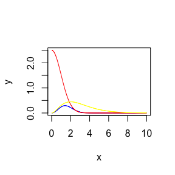

```r
# 设置随机数种子。
set.seed(42)
# 生成随机数个数。
n <- 1e6

# 生成服从标准正态分布和参数为1的瑞利分布的随机数。
r_norm <- rnorm(n)
r_rayleigh <- sqrt(-2 * log(runif(n)))

# 筛选出大于1的随机数，并计算其频率，用来估计对应概率。
r1 <- r_norm[r_norm>1]
r2 <- r_rayleigh[r_rayleigh>1]

p1 <- length(r1)/n
p2 <- length(r2)/n

# 画出g(x), f_1(x), f_2(x)的函数图象，进行比较，其中概率用频率估计。
x <- seq(0, 10, 0.01)
g <- x^2/(sqrt(2*pi))*exp(-x^2/2)
f_1 <- 1/(sqrt(2*pi))*exp(-x^2/2)/p1
f_2 <- x^2/2*exp(-x)/p2

plot(x, g, type = 'l', col='blue',ylim = c(0, 2.5), ylab = "y")
lines(x, f_1, type = 'l', col="red")
lines(x, f_2, type = 'l', col="yellow")
```

```r
# 估计量相关函数表达式。
g <- 1/sqrt(2*pi)*r1^2*exp(-x^2/2)
f1 <- 1/sqrt(2*pi)*exp(-x^2/2)/p1
f2 <- r2^2/2*exp(-r2^2/2)/p2

# 计算估计值及估计值的方差。
est1 <- mean(g/f1)
var1 <- var(g/f1)
est2 <- mean(g/f2)
var2 <- var(g/f2)
# 输出结果。
cat("由重要性函数f_1得到的积分估计值：",est1, end="\n")
```

```
## 由重要性函数f_1得到的积分估计值： 0.4013999
```

```r
cat("由重要性函数f_1得到的积分估计值的方差：",var1, end="\n")
```

```
## 由重要性函数f_1得到的积分估计值的方差： 0.06861075
```

```r
cat("由重要性函数f_2得到的积分估计值：",est2, end="\n")
```

```
## 由重要性函数f_2得到的积分估计值： 0.3908936
```

```r
cat("由重要性函数f_2得到的积分估计值的方差：",var2, end="\n")
```

```
## 由重要性函数f_2得到的积分估计值的方差： 36.33402
```

从图象可以看出，用标准正态分布函数来作为重要性函数，其方差减小效果比瑞利分布要好。

从实际随机数试验结果来看，标准正态分布作为重要性函数，估计方差为0.06861， 远小于瑞利分布函数作为重要性函数，得到的估计两方差36.33402。

但是两种重要性函数得到的估计值都是无偏的，与积分真实值0.40062相差不大。

## Question Monte Calro Experient

For $n=10^4, 2 \times 10^4, 4 \times 10^4, 6 \times 10^4, 8 \times 10^4$, apply the fast sorting algorithm to randomly permuted numbers of $1, \ldots, n$. Calculate computation time averaged over 100 simulations, denoted by $a_n$. Regress $a_n$ on $t_n:=n \log (n)$, and graphically show the results (scatter plot and regression line).

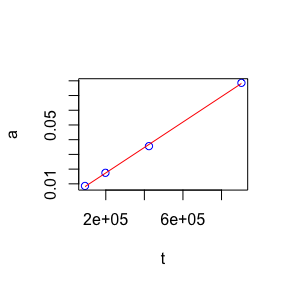

```r
# 定义快速排序法函数。
quick_sort<-function(x){
  num<-length(x)
  if(num==0||num==1){return(x)
  }else{
    a<-x[1]
    y<-x[-1]
    lower<-y[y<a]
    upper<-y[y>=a]
    return(c(quick_sort(lower),a,quick_sort(upper)))}#??????
}


# 定义生成的随机数个数并初始化。
n <-c(1, 2, 4, 8)*1e4
i <- 0
n_len <- length(n)
a <-c()

# 采用循环处理不同随机数个数的情况。
while(i<n_len){
  i <- i+1
  time_i <-c()
  j <- 0
  while(j<100){ # 对每个n，进行100次排序，计算平均时间。
    j <- j+1
    test<-sample(1:n[i])
    time_i[j] <- system.time(quick_sort(test))[1]
  }
  a[i] <- mean(time_i)
}

# 定义时间复杂度。
t <- n*log(n)

model <- lm(a~t)

a_predict <- predict(model)

plot(t, a, col="blue")
lines(t, a_predict, col="red")
```

```r
# 其统计结果输出。
summary(model)
```

```
##
## Call:
## lm(formula = a ~ t)
##
## Residuals:
##          1          2          3          4
##  0.0004670  0.0002397 -0.0011428  0.0004361
##
## Coefficients:
##              Estimate Std. Error t value Pr(>|t|)
## (Intercept) 1.337e-04  7.704e-04   0.174 0.878153
## t           8.642e-08  1.509e-09  57.284 0.000305 ***
## ---
## Signif. codes:  0 '***' 0.001 '**' 0.01 '*' 0.05 '.' 0.1 ' ' 1
##
## Residual standard error: 0.0009412 on 2 degrees of freedom
## Multiple R-squared:  0.9994, Adjusted R-squared:  0.9991
## F-statistic:  3281 on 1 and 2 DF,  p-value: 0.0003046
```

# ClassWork

## Solution

```r
d1 <- c(-2.961, 0.478, -0.391, -0.869, -0.460, -0.937, 0.779, -1.409, 0.027, -1.569)
d2 <- c(1.608, 1.009, 0.878, 1.600, -0.263, 0.680, 2.280, 2.390, 1.793, 8.091, 1.468)

set.seed(123)
B <- 1e4
theta_star <- numeric(B)
theta_0 <- mean(d1) - mean(d2)

for(i in 1:B){
  d1_star <- sample(d1, replace = T)
  d2_star <- sample(d2, replace = T)
  theta_star[i] <- mean(d1_star) - mean(d2_star)
}

round(c(theta=theta_0, se.boot=sd(theta_star), se.sample=sqrt(var(d1)/length(d1) + var(d2)/length(d2))), 3)
```

```
##     theta   se.boot se.sample
##    -2.689     0.714     0.739
```

# Hw_4

## Question 1

```r
set.seed(123)
N <- 1000
null_hypotheses <- 950
alt_hypotheses <- 50
alpha <- 0.1
m <- 10000

# 初始化结果矩阵
results <- matrix(0, nrow=3, ncol=2)
rownames(results) <- c("FWER", "FDR", "TPR")
colnames(results) <- c("Bonferroni correction", "B-H correction")

for (i in 1:m) {
  # 生成 p 值
  p_null <- runif(null_hypotheses)  # 从均匀分布生成 p 值
  p_alt <- rbeta(alt_hypotheses, 0.1, 1)  # 从 Beta 分布生成 p 值
  p_values <- c(p_null, p_alt)  # 合并 p 值

  # Bonferroni 校正
  p_bonferroni <- p.adjust(p_values, method = "bonferroni")
  reject_bonferroni <- p_bonferroni < alpha

  # B-H 校正
  p_bh <- p.adjust(p_values, method = "BH")
  reject_bh <- p_bh < alpha

  # 计算 FWER, FDR, TPR
  fwer_bonferroni <- any(reject_bonferroni[1:null_hypotheses])
  fdr_bonferroni <- ifelse(sum(reject_bonferroni) > 0,
                           sum(reject_bonferroni & !c(rep(FALSE, null_hypotheses), rep(TRUE, alt_hypotheses))) / sum(reject_bonferroni),
                           0)
  tpr_bonferroni <- sum(reject_bonferroni[(null_hypotheses + 1):N]) / alt_hypotheses

  fwer_bh <- any(reject_bh[1:null_hypotheses])
  fdr_bh <- ifelse(sum(reject_bh) > 0,
                   sum(reject_bh & !c(rep(FALSE, null_hypotheses), rep(TRUE, alt_hypotheses))) / sum(reject_bh),
                   0)
  tpr_bh <- sum(reject_bh[(null_hypotheses + 1):N]) / alt_hypotheses

  results[1, 1] <- results[1, 1] + fwer_bonferroni
  results[2, 1] <- results[2, 1] + fdr_bonferroni
  results[3, 1] <- results[3, 1] + tpr_bonferroni

  results[1, 2] <- results[1, 2] + fwer_bh
  results[2, 2] <- results[2, 2] + fdr_bh
  results[3, 2] <- results[3, 2] + tpr_bh
}

# 计算平均值
results <- results / m
results
```

```
##      Bonferroni correction B-H correction
## FWER           0.087300000     0.93050000
## FDR            0.004510088     0.09502215
## TPR            0.396736000     0.56106200
```

FWER: Bonferroni 校正控制 FWER 更好（0.0873），而 B-H 校正的 FWER 较高（0.9305），说明 Bonferroni 方法在控制错误拒绝零假设方面更有效。

FDR: Bonferroni 的 FDR 非常低（0.0045），这意味着在拒绝的假设中几乎没有错误，而 B-H 方法的 FDR 较高（0.0950），显示出 B-H 方法在发现真阳性时允许更多错误。

TPR: B-H 校正的 TPR 更高（0.5611），说明它在识别备择假设方面更有效，而 Bonferroni 方法的 TPR 较低（0.3967）。

## Question 7.4

```r
x <- c(3, 5, 7, 18, 43, 85, 91, 98, 100, 130, 230, 487)
n <- length(x)
lambda_hat <- n / sum(x)
lambda_hat
```

```
## [1] 0.00925212
```

```r
set.seed(123)
B <- 1000  # 自助重抽样次数
bootstrap_lambdas <- numeric(B)

for (b in 1:B) {
    sample_x <- sample(x, replace = TRUE)
    bootstrap_lambdas[b] <- length(sample_x) / sum(sample_x)
}

# 计算偏差和标准误差
bias <- mean(bootstrap_lambdas) - lambda_hat
se <- sd(bootstrap_lambdas)

# 输出结果
bias
```

```
## [1] 0.001582967
```

```r
se
```

```
## [1] 0.004452266
```

## question 7.5

```r
set.seed(123)
x <- c(3, 5, 7, 18, 43, 85, 91, 98, 100, 130, 230, 487)
n <- length(x)
lambda_hat <- n / sum(x)
mean_time <- 1 / lambda_hat
B <- 1000  # 自助重抽样次数
bootstrap_means <- numeric(B)

# 生成自助样本并计算平均时间
for (b in 1:B) {
    sample_x <- sample(x, replace = TRUE)
    bootstrap_lambda <- length(sample_x) / sum(sample_x)
    bootstrap_means[b] <- 1 / bootstrap_lambda
}

# 计算标准误差
se <- sd(bootstrap_means)

# 计算标准正态法置信区间
z <- qnorm(0.975)  # 95% 置信区间的 z 值
ci_normal <- c(mean_time - z * se, mean_time + z * se)

# 计算基本法置信区间
basic_ci <- quantile(bootstrap_means, c(0.025, 0.975))

# 计算百分位法置信区间
percentile_ci <- quantile(bootstrap_means, c(0.025, 0.975))

# 计算 BCa 置信区间
library(boot)
bca_ci <- boot.ci(boot.out = boot(data = x, statistic = function(data, indices) {
    lambda_hat <- length(data) / sum(data[indices])
    return(1 / lambda_hat)
}, R = B), type = "bca")

# 输出置信区间
ci_normal
```

```
## [1]  32.89198 183.27468
```

```r
basic_ci
```

```
##      2.5%     97.5%
##  47.39375 193.51875
```

```r
percentile_ci
```

```
##      2.5%     97.5%
##  47.39375 193.51875
```

```r
bca_ci$bca[4:5]  # BCa 区间
```

```
## [1]  57.41667 228.75700
```

标准正态法置信区间: 该方法基于中心极限定理，假设抽样分布是正态的，但在小样本情况下可能不准确。

基本法置信区间: 基本法计算原始样本和自助样本的差异，通常在分布不对称时表现较好。

百分位法置信区间: 直接基于自助样本的分位数，简单易用，但对极端值敏感。

BCa 方法: 经过偏差校正和加速的置信区间，通常能提供更精确的结果，尤其在样本分布不对称时。